# Toxicology study analysis

Mike Hutchens

2023-06-30

#Load the necessary packages

#Pull in the data and structure it for analysis.

```r
#get the data
tst<-read_csv("hdot_tst.csv")
wbc_all<-read_csv("hdot_tox_wbc_all_vals.csv")
#pivot the data
tst.long<-tst%>%pivot_longer(cols=8:10,names_to="tech", values_to="tst")
wbc.all.long<-wbc_all%>%pivot_longer(cols=6:11,names_to=c("hr","rep"),names_prefix = "r",names_sep="_",values_to="wbc")
#ensure that R sees the categoricals as categorical.
wbc.all.long<-wbc.all.long%>%mutate(treatment=factor(treatment))
tst.long<-tst.long%>%mutate(mouse=as.factor(mouse))
tst.long<-tst.long%>%mutate(sex=as.factor(sex))
tst.long<-tst.long%>%mutate(cagenum=as.factor(cagenum))
tst.long<-tst.long%>%mutate(tech=as.factor(tech))
tx<-tst.long$treatment
```

# Fit and analyse the WBC data

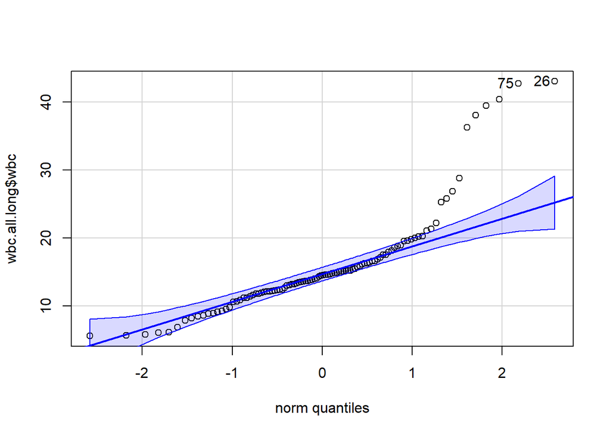

```
## [1] 26 75
```

```r
#use car and MASS to determine the distribution best fitting the data.
#WBC
qqp(wbc.all.long$wbc,"norm")
```

Wow, there are a lot of outliers (we knew that). We do outlier detection using z-scores, Grubb’s test, and Rosner’s test.

```r
#so lets do outlier detection here.
wbc.all.long<-wbc.all.long%>%mutate(wbc.z=round(abs(scale(wbc)),1))
grubbs.test(wbc.all.long$wbc) #there is at least one grubbs outlier
```

```
##
##  Grubbs test for one outlier
##
## data:  wbc.all.long$wbc
## G = 3.60973, U = 0.86971, p-value = 0.009882
## alternative hypothesis: highest value 43.06 is an outlier
```

```r
rosnerTest(wbc.all.long$wbc, k = 15)$all.stats #this identifies 6 outliers, >=36.3  Those values are at z>=2.5,
```

```
##     i   Mean.i     SD.i Value Obs.Num    R.i+1 lambda.i+1 Outlier
## 1   0 15.84725 7.538717 43.06      26 3.609731   3.390825    TRUE
## 2   1 15.57782 7.065545 42.76      75 3.847145   3.387474    TRUE
## 3   2 15.30600 6.548909 40.42      81 3.834837   3.384083    TRUE
## 4   3 15.05232 6.068360 39.52      82 4.032008   3.380651    TRUE
## 5   4 14.80265 5.565054 38.10      43 4.186365   3.377176    TRUE
## 6   5 14.56247 5.057700 36.30      19 4.297907   3.373658    TRUE
## 7   6 14.33604 4.563320 28.80      44 3.169613   3.370097   FALSE
## 8   7 14.18379 4.335481 26.92      50 2.937670   3.366490   FALSE
## 9   8 14.04830 4.151596 25.82      13 2.835465   3.362836   FALSE
## 10  9 13.92172 3.987564 25.30      14 2.853441   3.359136   FALSE
## 11 10 13.79804 3.825865 22.20      37 2.196094   3.355387   FALSE
## 12 11 13.70571 3.742578  5.62      78 2.160466   3.351588   FALSE
## 13 12 13.79556 3.663539  5.72      22 2.204305   3.347738   FALSE
## 14 13 13.88629 3.581150  5.86      34 2.241261   3.343836   FALSE
## 15 14 13.97750 3.496163  6.08      21 2.258905   3.339880   FALSE
```

```r
#which is a conservative cutoff.  Let's remove all values with z>2.5 for further analysis.
wbc.all.long.filt<-wbc.all.long%>%filter(wbc.z<2.5)
```

# Results of outlier detection

The Rosner test identifies 6 outliers, all >=36.3 Those values are at z>=2.5, which is a conservative cutoff. Let’s remove all values with z>2.5 for further analysis.

#Examine the data distribution

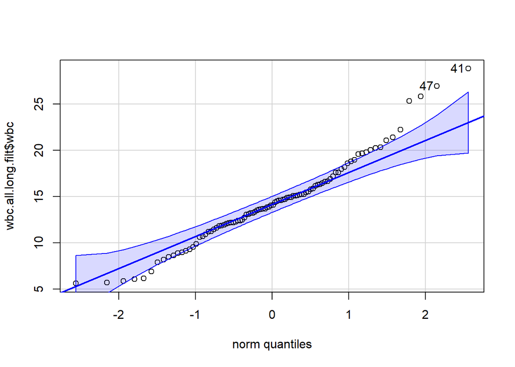

```
## [1] 41 47
```

```r
#find the distribution which fits all the remaining values best
qqp(wbc.all.long.filt$wbc,"norm")
```

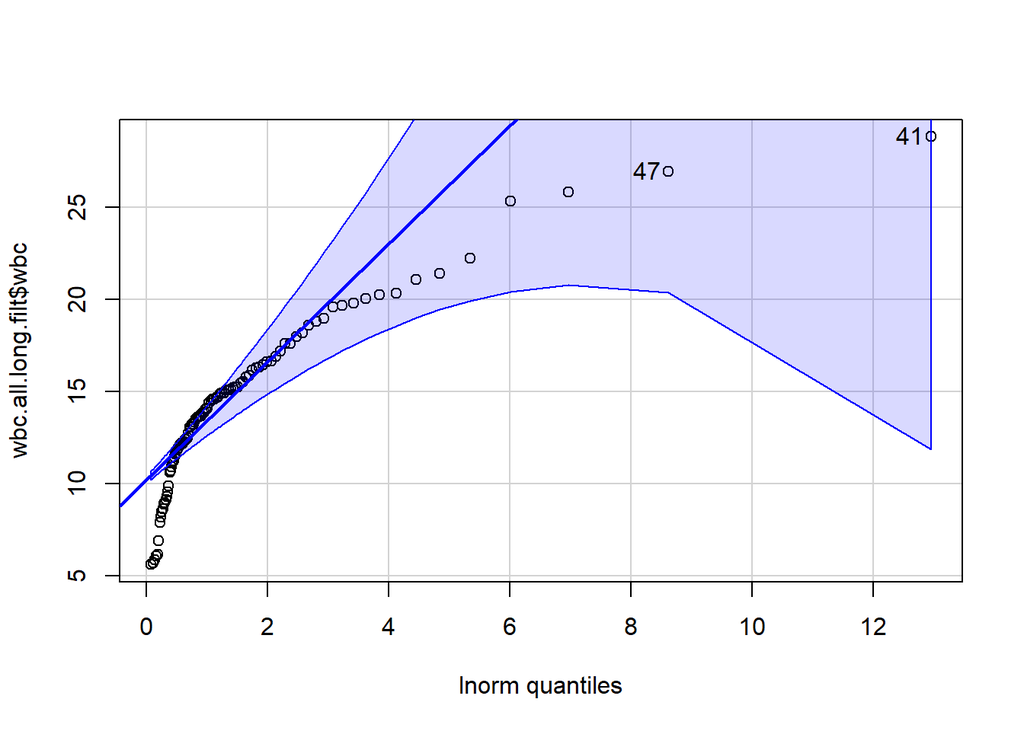

```
## [1] 41 47
```

```r
qqp(wbc.all.long.filt$wbc,"lnorm")
```

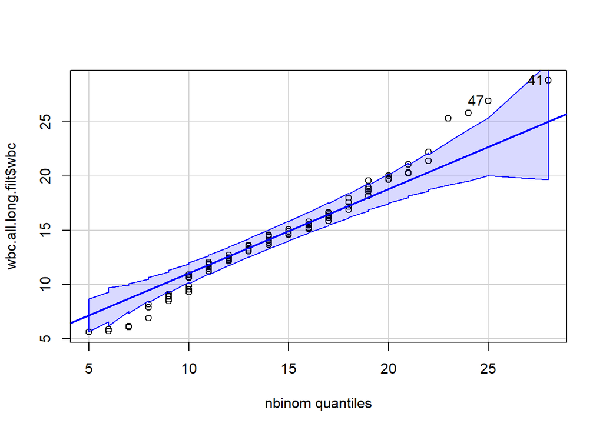

```
## [1] 41 47
```

```r
nbinom <- fitdistr(round((wbc.all.long.filt$wbc),0), "Negative Binomial")
qqp(wbc.all.long.filt$wbc, "nbinom", size = nbinom$estimate[[1]], mu = nbinom$estimate[[2]])
```

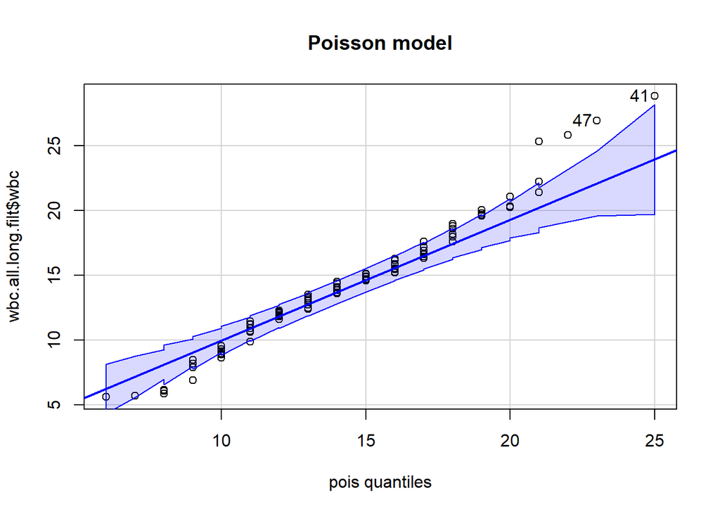

```
## [1] 41 47
```

```r
poisson <- fitdistr(round((wbc.all.long.filt$wbc),0), "Poisson")
qqp(wbc.all.long.filt$wbc, "pois", lambda=poisson$estimate, main="Poisson model")
```

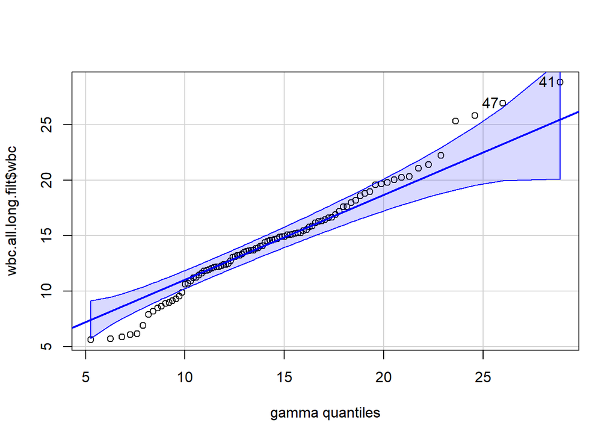

```
## [1] 41 47
```

```r
gamma <- fitdistr(round((wbc.all.long.filt$wbc),0),"gamma")
qqp(wbc.all.long.filt$wbc, "gamma", shape = gamma$estimate[[1]], rate = gamma$estimate[[2]])
```

Following outlier removal, WBC data is best fit with a normal distribution now, suggesting outlier removal was appropriate

# Preliminary statistical analysis

```r
#fix some datatype problems
wbc.all.long.filt<-wbc.all.long.filt%>%mutate(hr=as.integer(hr))
wbc.all.long.filt<-wbc.all.long.filt%>%mutate(rep=as.integer(rep))
wbc.all.long.filt<-wbc.all.long.filt%>%mutate(treatment=factor(treatment,levels=c("saline", "Dex","Dex-H dot","Cil-Dex H dot")))
wbc.all.long.filt<-wbc.all.long.filt%>%mutate(treatment=relevel(treatment, ref="Dex"))

t<-wbc.all.long.filt%>%filter((treatment=="saline")|(treatment=="Dex"))%>%filter(hr==0)
t.test(wbc~treatment, data=t)
```

```
##
##  Welch Two Sample t-test
##
## data:  wbc by treatment
## t = 1.3409, df = 12.995, p-value = 0.2029
## alternative hypothesis: true difference in means between group Dex and group saline is not equal to 0
## 95 percent confidence interval:
##  -2.182462  9.323891
## sample estimates:
##    mean in group Dex mean in group saline
##             21.64571             18.07500
```

Although nonsignificant, the Dex group WBC trends higher at time zero with p=0.2; this might obscure effect. therefore let’s look at delta – the change in WBC from time 0 to 4h, 0 to 8, and 4 to 8h.

```r
wbc.all.long.filt<-wbc.all.long.filt%>%group_by(mouse,rep)%>%mutate(delta=wbc-lag(wbc,order_by=hr))
wbc.all.long.filt<-wbc.all.long.filt%>%group_by(mouse,rep)%>%mutate(delta8=wbc-lag(wbc,n=2,order_by=hr))
t<-wbc.all.long.filt%>%filter((treatment=="saline")|(treatment=="Dex"))%>%filter(!is.na(delta))%>%filter(hr==4)
t.test(delta~treatment, data=t)
```

```
##
##  Welch Two Sample t-test
##
## data:  delta by treatment
## t = -2.6822, df = 12.757, p-value = 0.01908
## alternative hypothesis: true difference in means between group Dex and group saline is not equal to 0
## 95 percent confidence interval:
##  -12.670912  -1.353374
## sample estimates:
##    mean in group Dex mean in group saline
##            -10.91714             -3.90500
```

```r
t<-wbc.all.long.filt%>%filter((treatment=="saline")|(treatment=="Dex"))%>%filter(!is.na(delta))%>%filter(hr==8)
t.test(delta~treatment, data=t)
```

```
##
##  Welch Two Sample t-test
##
## data:  delta by treatment
## t = 1.1448, df = 13.461, p-value = 0.2722
## alternative hypothesis: true difference in means between group Dex and group saline is not equal to 0
## 95 percent confidence interval:
##  -2.628928  8.599928
## sample estimates:
##    mean in group Dex mean in group saline
##               2.3375              -0.6480
```

```r
t<-wbc.all.long.filt%>%filter((treatment=="saline")|(treatment=="Dex"))%>%filter(!is.na(delta8))
t.test(delta~treatment, data=t)
```

```
##
##  Welch Two Sample t-test
##
## data:  delta by treatment
## t = 1.3523, df = 10.611, p-value = 0.2044
## alternative hypothesis: true difference in means between group Dex and group saline is not equal to 0
## 95 percent confidence interval:
##  -2.475525 10.274097
## sample estimates:
##    mean in group Dex mean in group saline
##             2.634286            -1.265000
```

The maximum difference between Dex and saline was at hour 4. The bidirectional nature of Dex effect (WBC down, then up) does obscure the difference, as the magnitude of difference is reduced at 8 hours, both 8h-4h and 8h-0h. Therefore, to determine the relative effect of Cil/Dex/H-Dot, further analysis focuses on the 0-4 difference. Next, simple linear regression.

## Next plot with simple linear regression

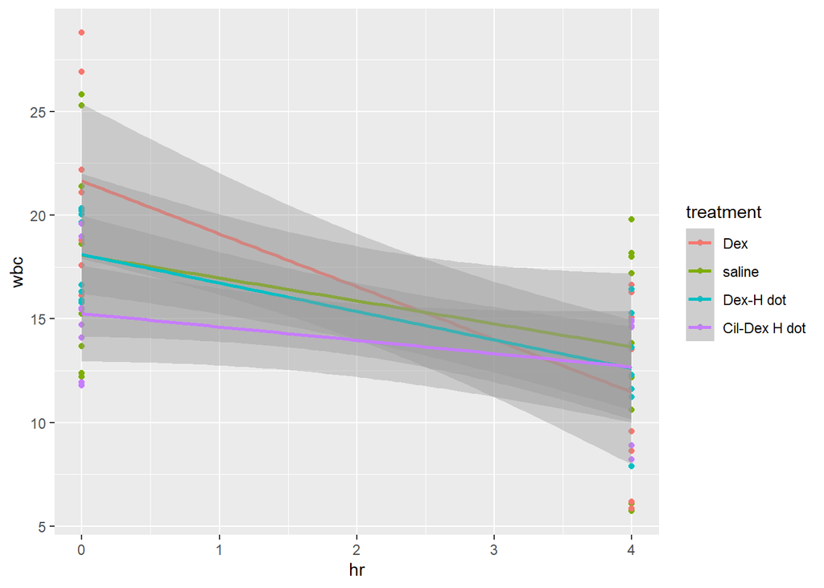

```r
t<-wbc.all.long.filt%>%filter(hr!=8)
ggplot(t,aes(x=hr,y=wbc, col=treatment))+
  geom_point()+
  geom_smooth(method="lm")
```

Perhaps the simplest way to do this analysis is do an ANOVA on the 4h delta…

## Perform ANOVA

```r
t<-wbc.all.long.filt%>%filter(hr!=8)
#here is the model
anova.a<-aov(delta~treatment, data=t) #AIC 338
summary(anova.a)
```

```
##             Df Sum Sq Mean Sq F value Pr(>F)
## treatment    3  335.4  111.80   5.913 0.0036 **
## Residuals   24  453.8   18.91
## ---
## Signif. codes:  0 '***' 0.001 '**' 0.01 '*' 0.05 '.' 0.1 ' ' 1
## 34 observations deleted due to missingness
```

```r
TukeyHSD(anova.a)
```

```
##   Tukey multiple comparisons of means
##     95% family-wise confidence level
##
## Fit: aov(formula = delta ~ treatment, data = t)
##
## $treatment
##                              diff        lwr       upr     p adj
## saline-Dex               7.012143  0.8039704 13.220315 0.0227438
## Dex-H dot-Dex            5.100000 -1.3117729 11.511773 0.1535298
## Cil-Dex H dot-Dex        9.680476  3.0068913 16.354061 0.0027604
## Dex-H dot-saline        -1.912143 -8.1203153  4.296030 0.8302143
## Cil-Dex H dot-saline     2.668333 -3.8098846  9.146551 0.6713011
## Cil-Dex H dot-Dex-H dot  4.580476 -2.0931087 11.254061 0.2573083
```

```r
#tt<-pairwise.t.test(dose_df$GFR, dose_df$dose, p.adj = "bonf")
#tt
```

## Therefore:

I think from this data we can conclude that **with respect to native Dex, Cil/Dex/H-Dot results in significantly less acute change in WBC relative to Dex (p=0.003, ANOVA)** .

## Plot the WBC data

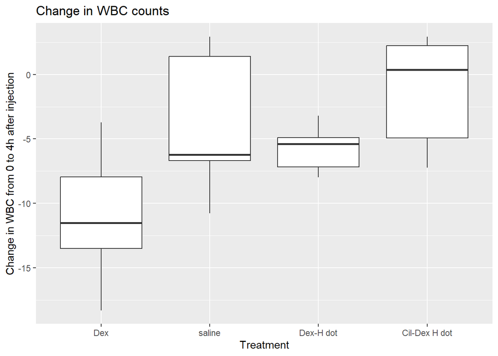

## TST data

Let’s plot this data first.

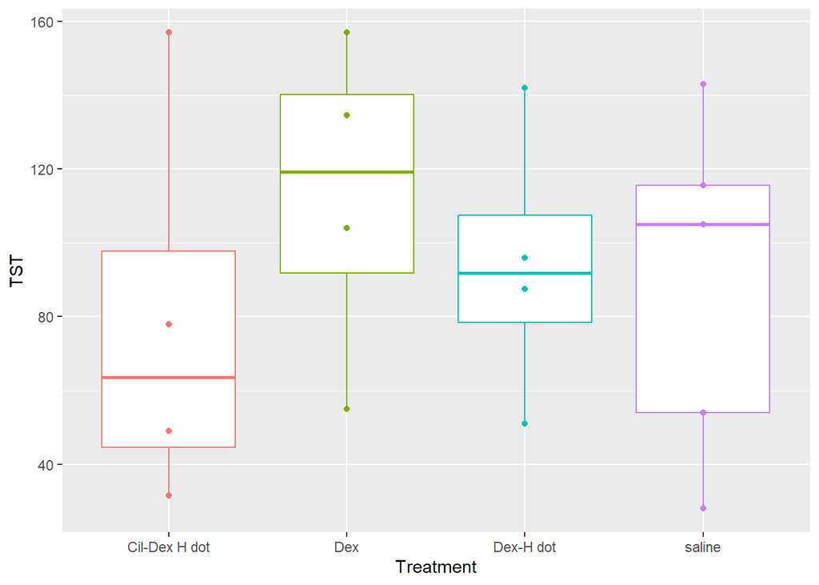

This data is suggestive, so let’s see if it needs cleaning up and proceed with statistical analysis.

```
##
##  Grubbs test for one outlier
##
## data:  tst.long$tst
## G = 1.62530, U = 0.91753, p-value = 1
## alternative hypothesis: highest value 164 is an outlier
```

There are no outliers in the TST data, lets see what distribution it fits best.

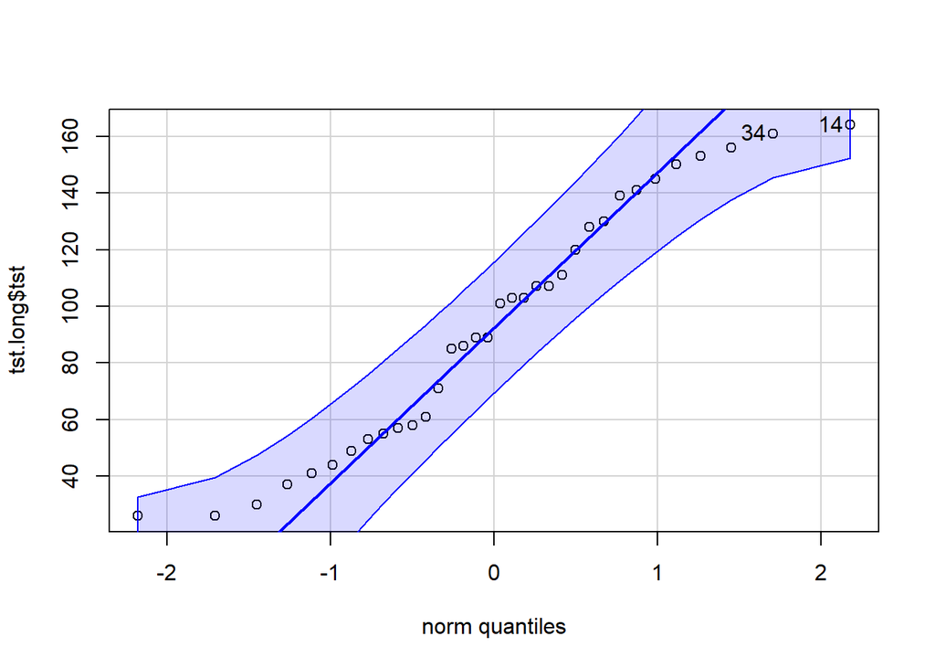

```
## [1] 14 34
```

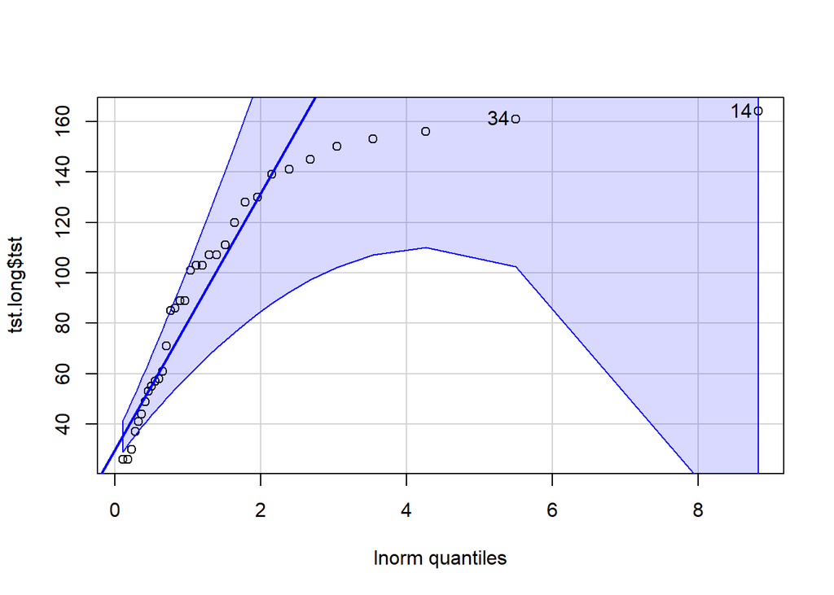

```
## [1] 14 34
```

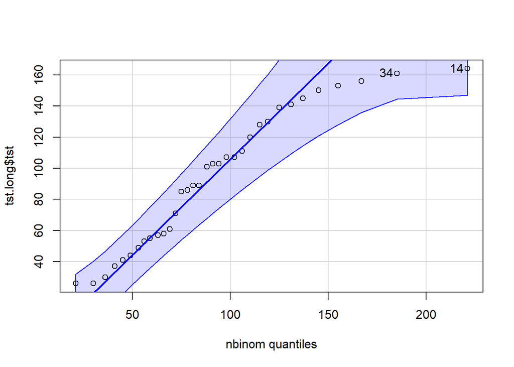

```
## [1] 14 34
```

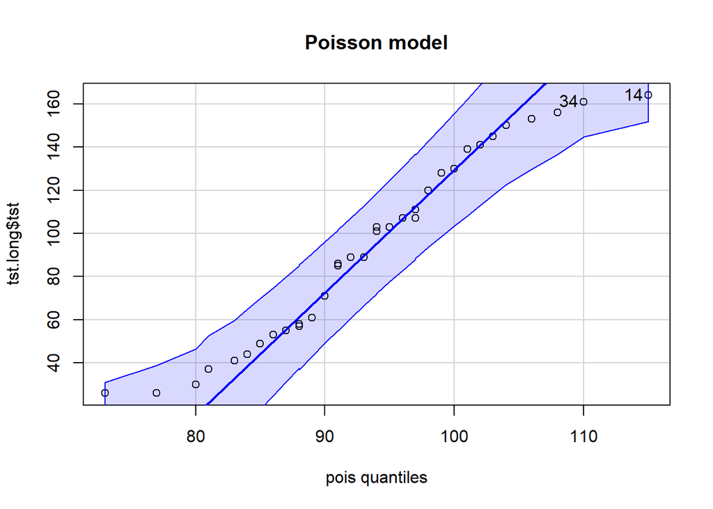

```
## [1] 14 34
```

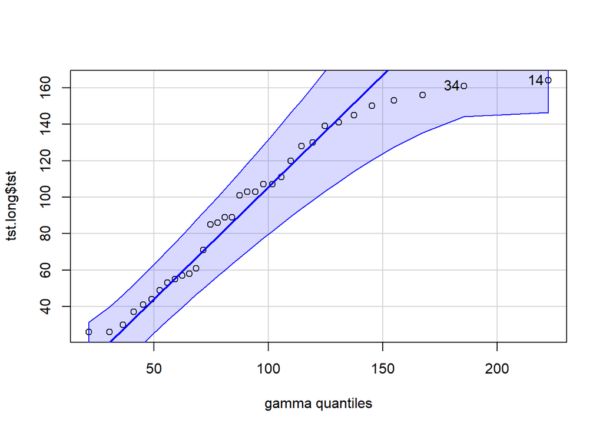

```
## [1] 14 34
```

The best fit is a normal distribution. Let’s start with ANOVA.

```
##             Df Sum Sq Mean Sq F value Pr(>F)
## treatment    3   2417   805.6   0.373  0.774
## Residuals   13  28103  2161.8
```

```
##   Tukey multiple comparisons of means
##     95% family-wise confidence level
##
## Fit: aov(formula = tst ~ treatment, data = t)
##
## $treatment
##                            diff        lwr       upr     p adj
## Dex-saline               23.525  -68.02044 115.07044 0.8732659
## Dex-H dot-saline          5.025  -86.52044  96.57044 0.9984321
## Cil-Dex H dot-saline    -10.225 -101.77044  81.32044 0.9872723
## Dex-H dot-Dex           -18.500 -114.99736  77.99736 0.9413628
## Cil-Dex H dot-Dex       -33.750 -130.24736  62.74736 0.7373891
## Cil-Dex H dot-Dex-H dot -15.250 -111.74736  81.24736 0.9656502
```

The ANOVA suggests there is no difference caused by treatment. But given the plotted data, it’s possible an effect is masked by variation the ANOVA cannot account for. Let’s try some linear mixed models.

```
## Linear mixed model fit by maximum likelihood . t-tests use Satterthwaite's
##   method [lmerModLmerTest]
## Formula: tst ~ relevel(treatment, ref = "Dex") + (1 | cagenum/mouse) +
##     age_wk + tech
##    Data: tst.long
##
##      AIC      BIC   logLik deviance df.resid
##    323.7    337.4   -152.8    305.7       25
##
## Scaled residuals:
##      Min       1Q   Median       3Q      Max
## -1.59371 -0.59976 -0.04436  0.49589  1.86167
##
## Random effects:
##  Groups        Name        Variance  Std.Dev.
##  mouse:cagenum (Intercept) 1.591e+03 39.888933
##  cagenum       (Intercept) 5.610e-06  0.002369
##  Residual                  6.789e+01  8.239488
## Number of obs: 34, groups:  mouse:cagenum, 17; cagenum, 5
##
## Fixed effects:
##                                              Estimate Std. Error      df
## (Intercept)                                    63.972     94.265  17.007
## relevel(treatment, ref = "Dex")saline         -25.100     27.198  17.000
## relevel(treatment, ref = "Dex")Dex-H dot      -19.813     28.608  17.000
## relevel(treatment, ref = "Dex")Cil-Dex H dot  -35.063     28.608  17.000
## age_wk                                          5.251      9.692  16.999
## techtech_M                                     -2.471      2.826  17.000
##                                              t value Pr(>|t|)
## (Intercept)                                    0.679    0.506
## relevel(treatment, ref = "Dex")saline         -0.923    0.369
## relevel(treatment, ref = "Dex")Dex-H dot      -0.693    0.498
## relevel(treatment, ref = "Dex")Cil-Dex H dot  -1.226    0.237
## age_wk                                         0.542    0.595
## techtech_M                                    -0.874    0.394
##
## Correlation of Fixed Effects:
##             (Intr) r(,r=" r(r="d rr="Hd age_wk
## rlv(,r="D") -0.054
## r(,r="D")Dd -0.068  0.531
## r(,r="D")Hd -0.068  0.531  0.504
## age_wk      -0.977 -0.107 -0.085 -0.085
## techtech_M  -0.015  0.000  0.000  0.000  0.000
```

AIC 323, not much variance by cage.

```
## Linear mixed model fit by maximum likelihood . t-tests use Satterthwaite's
##   method [lmerModLmerTest]
## Formula: tst ~ relevel(treatment, ref = "Dex") + (1 | mouse) + tech
##    Data: tst.long
##
##      AIC      BIC   logLik deviance df.resid
##    320.0    330.6   -153.0    306.0       27
##
## Scaled residuals:
##      Min       1Q   Median       3Q      Max
## -1.59337 -0.61062 -0.05605  0.48490  1.86201
##
## Random effects:
##  Groups   Name        Variance Std.Dev.
##  mouse    (Intercept) 1619.19  40.239
##  Residual               67.89   8.239
## Number of obs: 34, groups:  mouse, 17
##
## Fixed effects:
##                                              Estimate Std. Error      df
## (Intercept)                                   113.860     20.378  17.164
## relevel(treatment, ref = "Dex")saline         -23.525     27.275  17.000
## relevel(treatment, ref = "Dex")Dex-H dot      -18.500     28.750  17.000
## relevel(treatment, ref = "Dex")Cil-Dex H dot  -33.750     28.750  17.000
## techtech_M                                     -2.471      2.826  17.000
##                                              t value Pr(>|t|)
## (Intercept)                                    5.587 3.16e-05 ***
## relevel(treatment, ref = "Dex")saline         -0.863    0.400
## relevel(treatment, ref = "Dex")Dex-H dot      -0.643    0.529
## relevel(treatment, ref = "Dex")Cil-Dex H dot  -1.174    0.257
## techtech_M                                    -0.874    0.394
## ---
## Signif. codes:  0 '***' 0.001 '**' 0.01 '*' 0.05 '.' 0.1 ' ' 1
##
## Correlation of Fixed Effects:
##             (Intr) r(,r=" r(r="d rr="Hd
## rlv(,r="D") -0.744
## r(,r="D")Dd -0.705  0.527
## r(,r="D")Hd -0.705  0.527  0.500
## techtech_M  -0.069  0.000  0.000  0.000
```

AIC 320, a better fit than the first model.

```
## Linear mixed model fit by maximum likelihood . t-tests use Satterthwaite's
##   method [lmerModLmerTest]
## Formula: tst ~ relevel(treatment, ref = "Dex") + (1 | mouse) + age_wk +
##     tech
##    Data: tst.long
##
##      AIC      BIC   logLik deviance df.resid
##    321.7    333.9   -152.8    305.7       26
##
## Scaled residuals:
##      Min       1Q   Median       3Q      Max
## -1.59371 -0.59976 -0.04436  0.49589  1.86167
##
## Random effects:
##  Groups   Name        Variance Std.Dev.
##  mouse    (Intercept) 1591.12  39.889
##  Residual               67.89   8.239
## Number of obs: 34, groups:  mouse, 17
##
## Fixed effects:
##                                              Estimate Std. Error      df
## (Intercept)                                    63.972     94.265  17.008
## relevel(treatment, ref = "Dex")saline         -25.100     27.198  17.000
## relevel(treatment, ref = "Dex")Dex-H dot      -19.813     28.608  17.000
## relevel(treatment, ref = "Dex")Cil-Dex H dot  -35.063     28.608  17.000
## age_wk                                          5.251      9.692  17.000
## techtech_M                                     -2.471      2.826  17.000
##                                              t value Pr(>|t|)
## (Intercept)                                    0.679    0.506
## relevel(treatment, ref = "Dex")saline         -0.923    0.369
## relevel(treatment, ref = "Dex")Dex-H dot      -0.693    0.498
## relevel(treatment, ref = "Dex")Cil-Dex H dot  -1.226    0.237
## age_wk                                         0.542    0.595
## techtech_M                                    -0.874    0.394
##
## Correlation of Fixed Effects:
##             (Intr) r(,r=" r(r="d rr="Hd age_wk
## rlv(,r="D") -0.054
## r(,r="D")Dd -0.068  0.531
## r(,r="D")Hd -0.068  0.531  0.504
## age_wk      -0.977 -0.107 -0.085 -0.085
## techtech_M  -0.015  0.000  0.000  0.000  0.000
```

AIC 322, not better. Results the same as above. Let’s see confidence intervals on the second model.

```
##                                                     5 %      95 %
## .sig01                                        30.864916  55.20147
## .sigma                                         6.366597  11.24856
## (Intercept)                                   78.974178 148.74641
## relevel(treatment, ref = "Dex")saline        -70.233443  23.18344
## relevel(treatment, ref = "Dex")Dex-H dot     -67.735022  30.73502
## relevel(treatment, ref = "Dex")Cil-Dex H dot -82.985022  15.48502
## techtech_M                                    -7.310376   2.36920
```